# Лабораторный практикум ВКИАД c R

**Преподаватель**

```
Дорошко Ольга Валерьевна
```

**Студент**

```
Лозюк Илья Дмитриевич, 2 курс, 7 группа, ПМ
```

**Вариант № 2**

# Задание 1. Управление данными в R

Загрузка данных из текстового файла в переменную - таблицу данных

```r
qc=read.table("QC2.txt")
```

Размерность таблицы данных

```r
dim(qc)
```

```
## [1] 100   9
```

Первые три записи из таблицы

```r
head(qc, 3)
```

|  | V1 | V2 | V3 | V4 | V5 | V6 | V7 | V8 | V9 |
| --- | --- | --- | --- | --- | --- | --- | --- | --- | --- |
| 1 | 56.08 | 4 | 2 | 1 | 4 | 31.79 | 18.417 | 5.290 | 2 |
| 2 | 57.00 | 1 | 3 | 1 | 2 | 31.20 | 19.140 | 4.500 | 4 |
| 3 | 56.93 | 5 | 1 | 2 | 4 | 34.22 | 18.477 | 5.285 | 3 |

Таблица после переименования переменных

```r
names(qc) = c("c1", "kit", "nbug", "maker", "vendor", "c2", "c3", "c4", "bug")
head(qc, 3)
```

|  | c1 | kit | nbug | maker | vendor | c2 | c3 | c4 | bug |
| --- | --- | --- | --- | --- | --- | --- | --- | --- | --- |
| 1 | 56.08 | 4 | 2 | 1 | 4 | 31.79 | 18.417 | 5.290 | 2 |
| 2 | 57.00 | 1 | 3 | 1 | 2 | 31.20 | 19.140 | 4.500 | 4 |
| 3 | 56.93 | 5 | 1 | 2 | 4 | 34.22 | 18.477 | 5.285 | 3 |

Комплексная статистика по переменной vendor

```r
summary(qc$vendor)
```

```
##    Min. 1st Qu.  Median    Mean 3rd Qu.    Max.
##    1.00    1.75    2.00    2.49    4.00    4.00
```

Комплексная статистика по переменной vendor после ее преобразования в переменную-фактор

```r
summary(as.factor(qc[,"vendor"]))
```

```
##  1  2  3  4
## 25 28 20 27
```

Число изделий, у которых число некритических дефектов (nbug) больше 3

```r
sum(qc$nbug > 3)
```

```
## [1] 11
```

Наблюдения, для которых количество некритических дефектов равно максимальному

```r
qc[max(qc[,"nbug"]) == qc[,"nbug"],]
```

|  | c1 | kit | nbug | maker | vendor | c2 | c3 | c4 | bug |
| --- | --- | --- | --- | --- | --- | --- | --- | --- | --- |
| 15 | 53.93 | 3 | 6 | 2 | 1 | 31.69 | 18.006 | 5.080 | 3 |
| 72 | 57.19 | 7 | 6 | 1 | 1 | 30.27 | 18.930 | 4.925 | 3 |

# Задание 2. Описательная статистика и графический анализ

Присоединение таблицы данных к списку текущих переменных и загрузка дополнительной библиотеки

```r
attach(qc)
library("e1071")
```

Выборочные среднее и медиана для переменной с1 в указанном порядке

```r
mean(c1)
```

```
## [1] 55.0549
```

```r
median(c1)
```

```
## [1] 54.855
```

Выборочные квартили Q1,Q2,Q3 , а также интерквартильный размах для переменной c1

```r
quantile(c1, seq(0.25, 0.75, 0.25))
```

```
##     25%     50%     75%
## 53.6525 54.8550 56.5250
```

```r
IQR(c1)
```

```
## [1] 2.8725
```

Комплексная статистика по переменной c1

```r
summary(c1)
```

```
##    Min. 1st Qu.  Median    Mean 3rd Qu.    Max.
##   49.68   53.65   54.85   55.05   56.52   59.94
```

Дисперсия для переменной с1 и переменной, которая представляет собой линейную комбинацию первой

```r
var(c1)
```

```
## [1] 4.628207
```

```r
var(c1 * 2 + 100)
```

```
## [1] 18.51283
```

**Вывод:** вторая дисперсия больше в 4 раза.

Дисперсия для переменно с1, вычесленная с использованием векторного выражения

```r
sum((mean(c1)-c1)^2/(length(c1) - 1))
```

```
## [1] 4.628207
```

Гистограмма для переменной с1

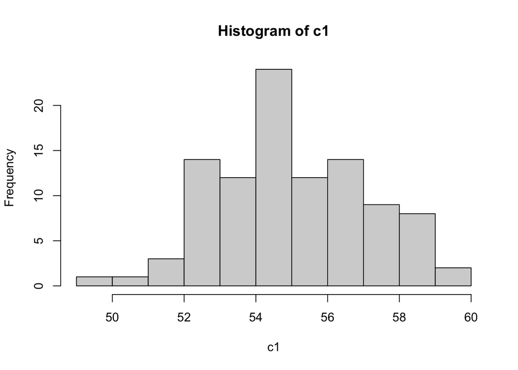

```r
hist(c1)
```

Асимметрия и эксцесс переменной c1 в указанном порядке

```r
skewness(c1)
```

```
## [1] 0.03317255
```

```r
kurtosis(c1)
```

```
## [1] -0.4727926
```

Проверка распределения переменной c1 на нормальность с помощью статистического теста Лиллиефорса

```r
library(nortest)
lillie.test(c1)
```

```
##
##  Lilliefors (Kolmogorov-Smirnov) normality test
##
## data:  c1
## D = 0.0772, p-value = 0.151
```

**Вывод:** гипотеза о нормальном распределении не отклоняется на уровне значимости 0.05.

# Задание 3. Анализ статистических зависимостей

Перекодировка переменной kit в переменную с двумя значениями (1 и 2)

```r
kit = ifelse(kit < 3, 1, 2)
```

Ранговый коэффициент корреляции Спирмена для переменных kit и maker

```r
cor(kit, maker, method="spearman")
```

```
## [1] 0.08173077
```

Таблица сопряженности для переменных kit и maker

```r
table(kit, maker)
```

```
##    maker
## kit  1  2
##   1 27 21
##   2 25 27
```

**Вывод:** согласно ранговому коэффициенту корреляции и таблице сопряженности согласованность между переменными практически отсутствует.

Тест на равенство нулю коэффициента корреляции для переменных с1,с3

```r
cor.test(c1, c3)
```

```
##
##  Pearson's product-moment correlation
##
## data:  c1 and c3
## t = 21.001, df = 98, p-value < 2.2e-16
## alternative hypothesis: true correlation is not equal to 0
## 95 percent confidence interval:
##  0.8611169 0.9348641
## sample estimates:
##       cor
## 0.9045418
```

**Вывод:** гипотеза о равенстве нулю коэффициента корреляции между переменными отклоняется на уровне значимости 0.05.

Корреляционная матрица для числовых характеристик с1-c4

```r
cor(qc[,c("c1", "c2", "c3", "c4")])
```

```
##            c1          c2         c3          c4
## c1  1.0000000 -0.20389934  0.9045418  0.38674144
## c2 -0.2038993  1.00000000 -0.1960740 -0.09152175
## c3  0.9045418 -0.19607400  1.0000000  0.50604092
## c4  0.3867414 -0.09152175  0.5060409  1.00000000
```

Матрица корреляции в удобном представлении

```r
symnum(cor(qc[,c("c1", "c2", "c3", "c4")]))
```

```
##    c1 c2 c3 c4
## c1 1
## c2    1
## c3 *     1
## c4 .     .  1
## attr(,"legend")
## [1] 0 ' ' 0.3 '.' 0.6 ',' 0.8 '+' 0.9 '*' 0.95 'B' 1
```

**Вывод:** наибольший коэффициент корреляции между переменными c1 и с3.

Построение регрессионной модели по переменным c1 (зависимая - отклик) и с3 (независимая - фактор) и вывод общей статистики по результатам оценивания.

```r
linmod = lm(c1 ~ c3)
summary(linmod)
```

```
##
## Call:
## lm(formula = c1 ~ c3)
##
## Residuals:
##      Min       1Q   Median       3Q      Max
## -2.36553 -0.60136 -0.01133  0.58398  2.86565
##
## Coefficients:
##             Estimate Std. Error t value Pr(>|t|)
## (Intercept)   6.1747     2.3293   2.651  0.00936 **
## c3            2.6748     0.1274  21.001  < 2e-16 ***
## ---
## Signif. codes:  0 '***' 0.001 '**' 0.01 '*' 0.05 '.' 0.1 ' ' 1
##
## Residual standard error: 0.922 on 98 degrees of freedom
## Multiple R-squared:  0.8182, Adjusted R-squared:  0.8163
## F-statistic:   441 on 1 and 98 DF,  p-value: < 2.2e-16
```

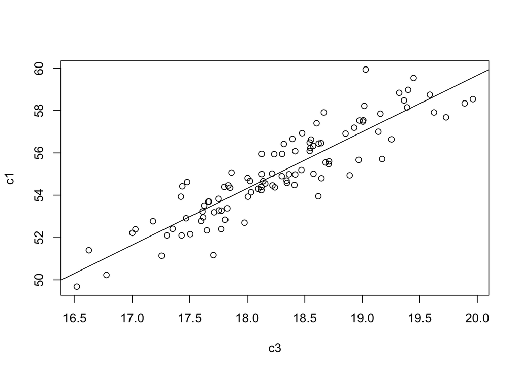

```r
plot(c3, c1)
abline(linmod)
```

Коэффициенты модели

```r
coefficients(linmod)
```

```
## (Intercept)          c3
##    6.174723    2.674845
```

График “Квантиль-квантиль” для остатков модели

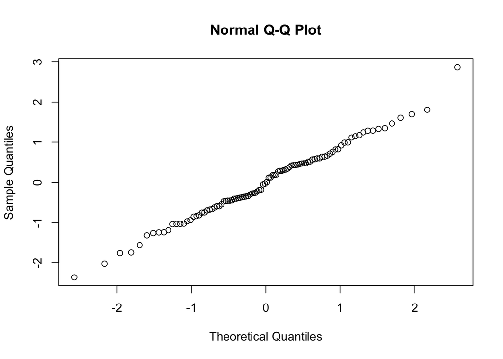

```r
res = residuals(linmod)
qqnorm(res)
```

**Вывод:** большинство точек располагаются вблизи прямой линии, поэтому распределение остатков близко к нормальному.

Тест Колмогорова-Смирнова на нормальность остатков

```r
ks.test(res, pnorm, mean(res), sd(res))
```

```
##
##  One-sample Kolmogorov-Smirnov test
##
## data:  res
## D = 0.061976, p-value = 0.8371
## alternative hypothesis: two-sided
```

**Вывод:** критерий не отклоняет гипотезу о нормальном распределении на уровне значимости 0.05.

# Задание 4. Анализ неоднородных данных

Частоты значений для переменной maker

```r
table(maker)
```

```
## maker
##  1  2
## 52 48
```

Двухвыборочный t-критерий по переменной c2 c разбиением на подвыборки по переменной maker

```r
t.test(c2 ~ maker)
```

```
##
##  Welch Two Sample t-test
##
## data:  c2 by maker
## t = -5.036, df = 95.109, p-value = 2.253e-06
## alternative hypothesis: true difference in means is not equal to 0
## 95 percent confidence interval:
##  -1.942217 -0.843905
## sample estimates:
## mean in group 1 mean in group 2
##        32.02423        33.41729
```

**Вывод:** гипотеза о равенстве средних в двух подвыборках отклоняется на уровне значимости 0.05 для переменной c2(средние значения характеристики c2 у двух производителей статистически различимы).

“Ящики с усами” для переменной с2 в разрезе по номеру производителя (maker)

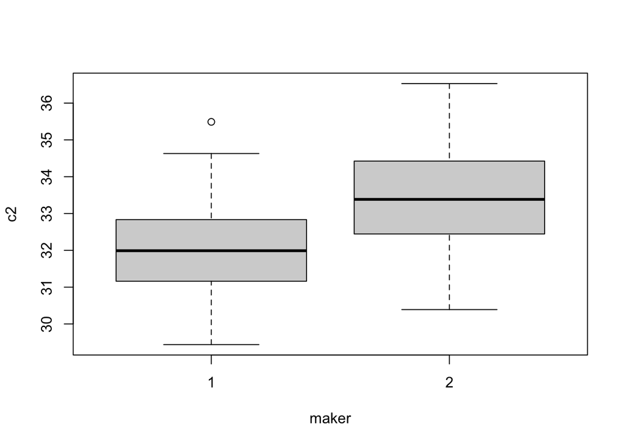

```r
boxplot(c2 ~ maker)
```

График ядерной оценки плотности распределения для переменной c2

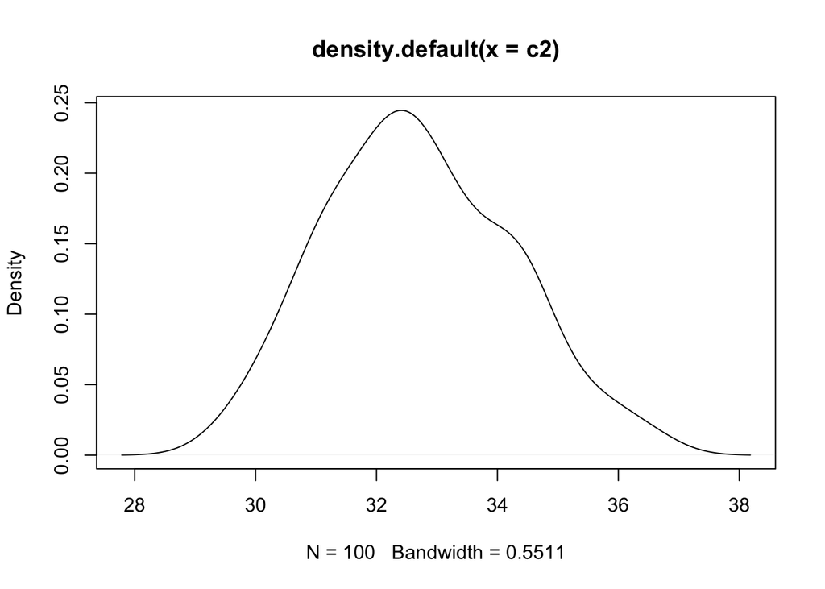

```r
plot(density(c2))
```

**Вывод:** из графика видно, что выборка описывается моделью, которая представляет собой смесь двух распределений.

# Задание 5. Классификация неоднородных данных

Диаграмма рассеяния переменных с2 и с4, для которых коэффициент корреляции принимает наиболее близкое к нулю значение

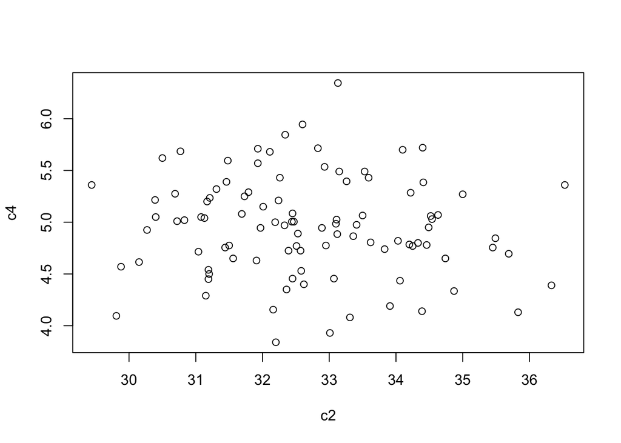

```r
plot(c2, c4)
```

Первые строки матрицы из переменных c2 и с4

```r
bind1 = cbind(c2, c4)
head(bind1, 3)
```

```
##         c2    c4
## [1,] 31.79 5.290
## [2,] 31.20 4.500
## [3,] 34.22 5.285
```

Применение кластерного анализа и вывод частот наблюдений в каждом оцененном классе

```r
kmres = kmeans(bind1, 2)
table(kmres$cluster)
```

```
##
##  1  2
## 56 44
```

График с классовой принадлежностью наблюдений

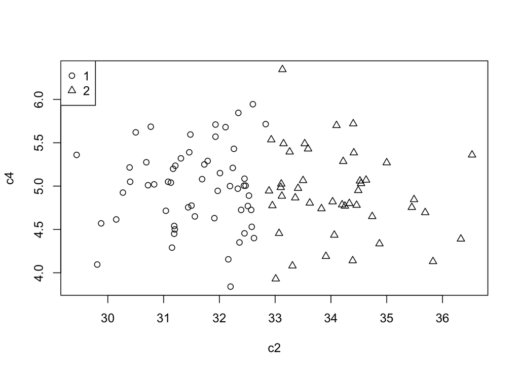

```r
plot(bind1, pch=kmres$cluster)
legend("topleft", legend = c(1, 2), pch = c(1, 2))
```

Работа с данными закончена

```r
detach(qc)
```